# Tweet Thread

# Tweet One

Hi Argo community! I want to introduce you to a newly developed R package, argoFloats. This package was created by myself, Dan Kelley, and Jaimie Harbin to provide tools for downloading and analyzing collections of oceanographic Argo float datasets.

# Tweet Two

argoFloats has an easy-to-follow work flow, to allow the users to effectively access, download, and read Argo data.

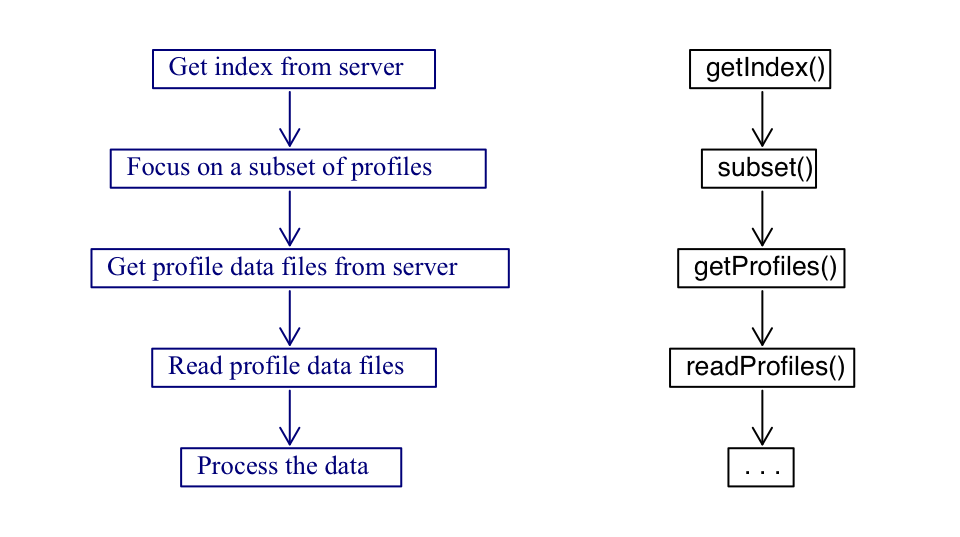

Figure 1: Work flow of the argoFloats package.

# Tweet Three

To get familiar with argoFloats, check out the user website, https://argocanada.github.io/argoFloats/index.html, or developer website https://github.com/ArgoCanada/argoFloats for more advanced R users.

# Tweet Four

Users can easily sift through data based on geographical region, parameter, time, institution, deep Argo, ID, ocean, mode, and profile. A series of real-time examples exists at our Youtube channel https://www.youtube.com/channel/UCmVBNwRRGx5sRa1skvfOrvA.

# Tweet Five

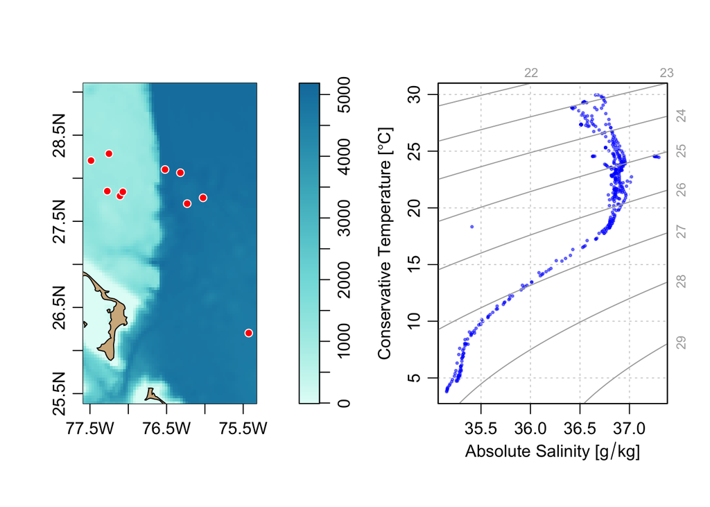

```r
library(argoFloats)
# Get world index
data(index)
# Get index withing 50km of Bermuda
ais <- subset(index, 1:10)
# Get profile data files for this near-Bermuda index
pr <- getProfiles(ais)
# Read those data files
a <- readProfiles(pr, handleFlags=TRUE)
# Plot a map to the left, and a TS diagram to the right
par(mfrow=c(1, 2))
plot(a, which="map")
plot(a, which='TS')
```

# Tweet Six

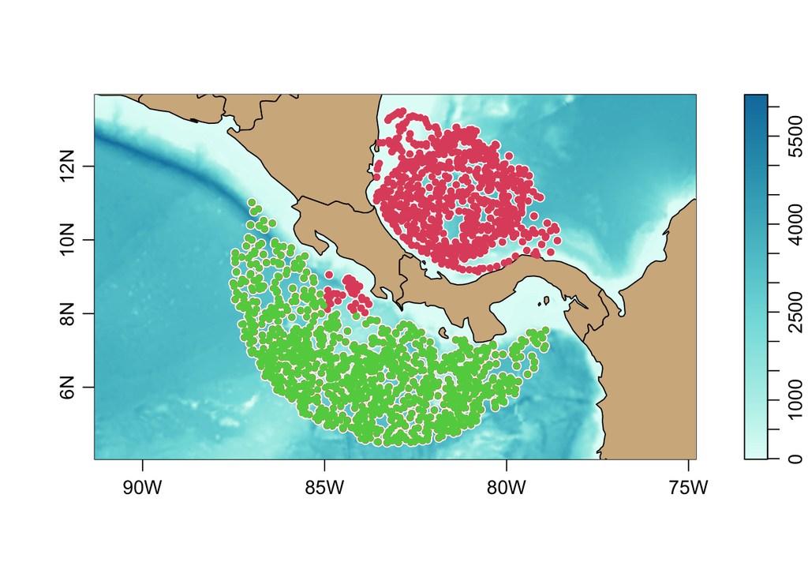

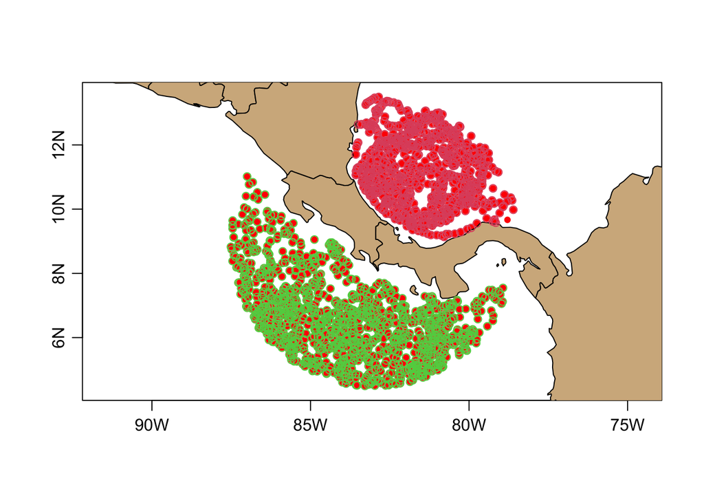

```r
library(argoFloats)
ai <- getIndex()
s <- subset(ai, circle=list(longitude=-83, latitude=9, radius=500))
plot(s, which='map') # To get a visual
atlantic <- subset(s, ocean='A') # Subsetting for Atlantic Ocean
pacific <- subset(s, ocean='P')
points(atlantic[['longitude']], atlantic[['latitude']], pch=20, col=2)
points(pacific[['longitude']], pacific[['latitude']], pch=20, col=3)
```

# Tweet 07

The code found at https://github.com/ArgoCanada/argoFloats/blob/develop/videos/05/video05_TS_by_oxygen.R demonstrates how to use the argoFloats package to TS diagram, colour-coded by oxygen.

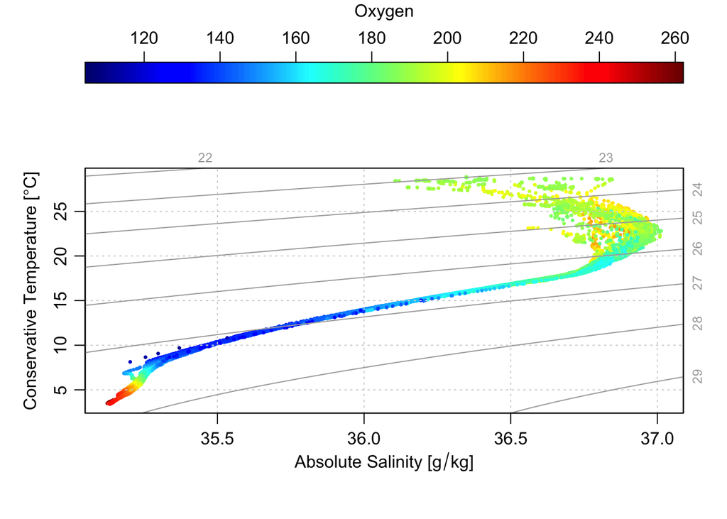

# Tweet 08

Bathymetry has recently been added to the argoFloats package. If you visit https://github.com/ArgoCanada/argoFloats/blob/develop/videos/07/video07_map_with_bathymetry.R you can find code to create a trajectory plot, colour coded by time, with bathymetry.

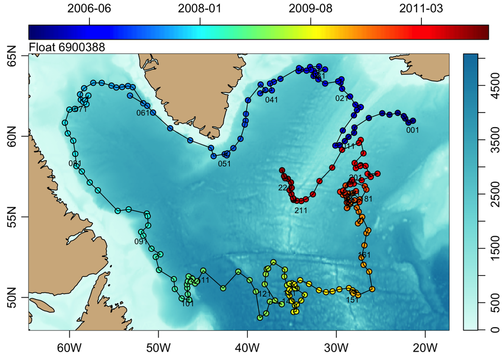